# Project Practical Machine Learning

Jose Nicolas Molina

2022-09-11

## Introduction

The goal of this project is to predict how six participants performed barbell lifts correctly and incorrectly in five different ways. Data from accelerometers attached to the belt, forearm, upper arm, and dumbbell are used to determine how well each participant was performing the barbell lifts. The machine learning algorithm that is developed in this report is applied to 20 test cases available in the test data. The predictions are used for the project prediction evaluation questionnaire for qualification.

## Data Loading, Packages and Library

Download data from url:

```r
dataTrain <- "http://d396qusza40orc.cloudfront.net/predmachlearn/pml-training.csv"

dataTest <- "http://d396qusza40orc.cloudfront.net/predmachlearn/pml-testing.csv"
```

Load the datasets

```r
training <- read.csv(url(dataTrain))
testing  <- read.csv(url(dataTest))
```

Load packages and library

```r
library(knitr)
library(caret)
```

```r
library(rpart)
library(rpart.plot)
library(rattle)
library(randomForest)
library(corrplot)
```

Data spliting

A training data set (70%) will be created for the modeling process and a test data set (30%) for validations. The testing data set is used in the choice of results for the prediction quiz.

```r
inTrain  <- createDataPartition(training$classe, p=0.7, list=FALSE)
trainSet <- training[inTrain, ]
testSet  <- training[-inTrain, ]
```

Exploratory Analysis and Cleaning

```r
dim(trainSet)
```

```
## [1] 13737   160
```

```r
dim(testSet)
```

```
## [1] 5885  160
```

Note: The data created from trainSet and testSet contains 160 variables. In the variables there are NA, which will be applied cleaning. Likewise, unnecessary variables such as Nearly Zero Variance and id are eliminated.

Remove NAs in variables

```r
nonNA    <- sapply(trainSet, function(x) mean(is.na(x))) > 0.95
trainSet <- trainSet[, nonNA==FALSE]
testSet  <- testSet[, nonNA==FALSE]
```

```r
dim(trainSet)
```

```
## [1] 13737    93
```

```r
dim(testSet)
```

```
## [1] 5885   93
```

Remove variables with almost zero variance

```r
neZeVar <- nearZeroVar(trainSet)
trainSet <- trainSet[, -neZeVar]
testSet  <- testSet[, -neZeVar]
```

```r
dim(trainSet)
```

```
## [1] 13737    59
```

```r
dim(testSet)
```

```
## [1] 5885   59
```

Remove id variables

```r
trainSet <- trainSet[, -(1:5)]
testSet  <- testSet[, -(1:5)]
```

```r
dim(trainSet)
```

```
## [1] 13737    54
```

```r
dim(testSet)
```

```
## [1] 5885   54
```

Note: 54 will be the variables that will be analyzed after the cleaning process.

Correlation Analysis

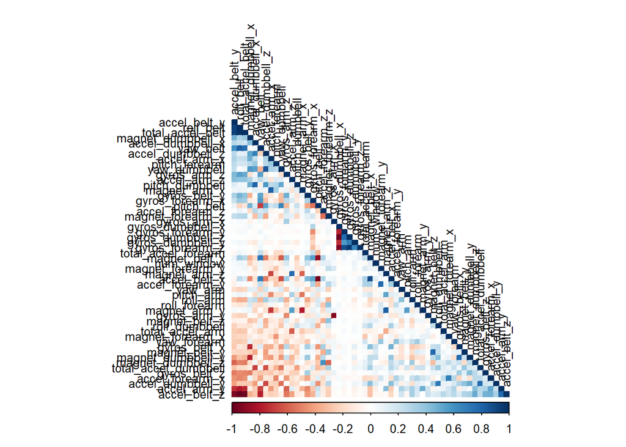

```r
cMatrix <- cor(trainSet[, -54])
corrplot(cMatrix, order = "FPC", method = "color", type = "lower",
         tl.cex = 0.8, tl.col = rgb(0, 0, 0))
```

Note: Variables with high correlations are presented in dark colors.

## Prediction Model Building

Random Forest, Decision Trees and Generalized Boosted Model methods are applied to model the regressions. The one with the highest precision, when applied to the test data set, is used in the predictions of the questionnaire.

### Random Forest

Model fit

```r
fitRfc <- trainControl(method="cv", number=3, verboseIter=FALSE)
modFitRf <- train(classe ~ ., data=trainSet, method="rf",
                          trControl=fitRfc)
modFitRf$finalModel
```

```
##
## Call:
##  randomForest(x = x, y = y, mtry = param$mtry)
##                Type of random forest: classification
##                      Number of trees: 500
## No. of variables tried at each split: 27
##
##         OOB estimate of  error rate: 0.26%
## Confusion matrix:
##      A    B    C    D    E  class.error
## A 3904    1    0    0    1 0.0005120328
## B    6 2650    2    0    0 0.0030097818
## C    0    5 2391    0    0 0.0020868114
## D    0    0   12 2239    1 0.0057726465
## E    0    1    0    7 2517 0.0031683168
```

Prediction on test dataset

```r
predictRf <- predict(modFitRf, newdata=testSet)
confMatRf <- confusionMatrix(predictRf, as.factor(testSet$classe))
confMatRf
```

```
## Confusion Matrix and Statistics
##
##           Reference
## Prediction    A    B    C    D    E
##          A 1674    4    0    0    0
##          B    0 1133    1    0    0
##          C    0    2 1022    3    0
##          D    0    0    3  961    1
##          E    0    0    0    0 1081
##
## Overall Statistics
##
##                Accuracy : 0.9976
##                  95% CI : (0.996, 0.9987)
##     No Information Rate : 0.2845
##     P-Value [Acc > NIR] : < 2.2e-16
##
##                   Kappa : 0.997
##
##  Mcnemar's Test P-Value : NA
##
## Statistics by Class:
##
##                      Class: A Class: B Class: C Class: D Class: E
## Sensitivity            1.0000   0.9947   0.9961   0.9969   0.9991
## Specificity            0.9991   0.9998   0.9990   0.9992   1.0000
## Pos Pred Value         0.9976   0.9991   0.9951   0.9959   1.0000
## Neg Pred Value         1.0000   0.9987   0.9992   0.9994   0.9998
## Prevalence             0.2845   0.1935   0.1743   0.1638   0.1839
## Detection Rate         0.2845   0.1925   0.1737   0.1633   0.1837
## Detection Prevalence   0.2851   0.1927   0.1745   0.1640   0.1837
## Balanced Accuracy      0.9995   0.9973   0.9975   0.9980   0.9995
```

Plot matrix results

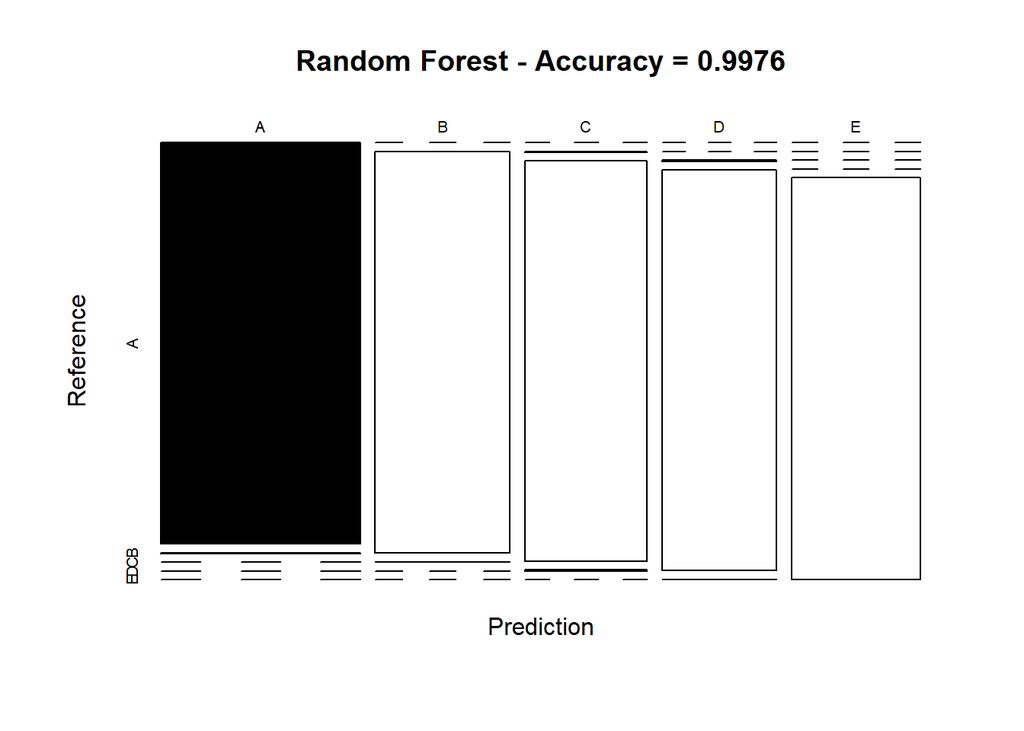

```r
plot(confMatRf$table, col = confMatRf$byClass,
     main = paste("Random Forest - Accuracy =",
                  round(confMatRf$overall['Accuracy'], 4)))
```

### Decision Trees

Model fit

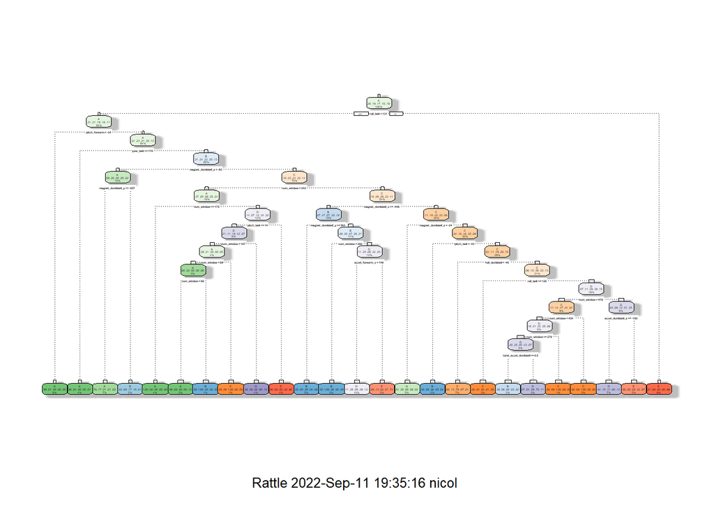

```r
set.seed(12345)
modFitDTree <- rpart(classe ~ ., data=trainSet, method="class")
fancyRpartPlot(modFitDTree)
```

Prediction on test dataset

```r
predictDTree <- predict(modFitDTree, newdata=testSet, type="class")
confMatDTree <- confusionMatrix(predictDTree, as.factor(testSet$classe))
confMatDTree
```

```
## Confusion Matrix and Statistics
##
##           Reference
## Prediction    A    B    C    D    E
##          A 1519  181   16   52   26
##          B   40  665   52   48   32
##          C    1   59  827   38    4
##          D  106  207  123  751  179
##          E    8   27    8   75  841
##
## Overall Statistics
##
##                Accuracy : 0.7822
##                  95% CI : (0.7714, 0.7926)
##     No Information Rate : 0.2845
##     P-Value [Acc > NIR] : < 2.2e-16
##
##                   Kappa : 0.7243
##
##  Mcnemar's Test P-Value : < 2.2e-16
##
## Statistics by Class:
##
##                      Class: A Class: B Class: C Class: D Class: E
## Sensitivity            0.9074   0.5838   0.8060   0.7790   0.7773
## Specificity            0.9347   0.9638   0.9790   0.8750   0.9754
## Pos Pred Value         0.8467   0.7945   0.8902   0.5498   0.8770
## Neg Pred Value         0.9621   0.9061   0.9598   0.9529   0.9511
## Prevalence             0.2845   0.1935   0.1743   0.1638   0.1839
## Detection Rate         0.2581   0.1130   0.1405   0.1276   0.1429
## Detection Prevalence   0.3048   0.1422   0.1579   0.2321   0.1630
## Balanced Accuracy      0.9211   0.7738   0.8925   0.8270   0.8763
```

Plot matrix results

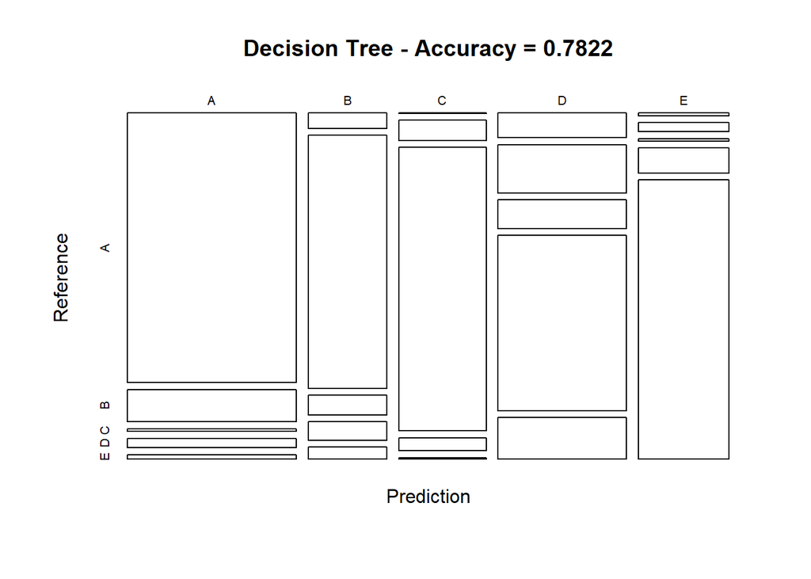

```r
plot(confMatDTree$table, col = confMatDTree$byClass,
     main = paste("Decision Tree - Accuracy =",
                  round(confMatDTree$overall['Accuracy'], 4)))
```

### Generalized Boosted Model

Model fit

```r
set.seed(12345)
fitGBM <- trainControl(method = "repeatedcv", number = 5, repeats = 1)
modFitGBM  <- train(classe ~ ., data=trainSet, method = "gbm",
                    trControl =fitGBM, verbose = FALSE)
modFitGBM$finalModel
```

```
## A gradient boosted model with multinomial loss function.
## 150 iterations were performed.
## There were 53 predictors of which 53 had non-zero influence.
```

Prediction on test dataset

```r
predictGBM <- predict(modFitGBM, newdata=testSet)
cfMatGBM <- confusionMatrix(predictGBM, as.factor(testSet$classe))
cfMatGBM
```

```
## Confusion Matrix and Statistics
##
##           Reference
## Prediction    A    B    C    D    E
##          A 1668   18    0    0    0
##          B    6 1113    6   10    4
##          C    0    6 1015    9    0
##          D    0    2    5  942   10
##          E    0    0    0    3 1068
##
## Overall Statistics
##
##                Accuracy : 0.9866
##                  95% CI : (0.9833, 0.9894)
##     No Information Rate : 0.2845
##     P-Value [Acc > NIR] : < 2.2e-16
##
##                   Kappa : 0.983
##
##  Mcnemar's Test P-Value : NA
##
## Statistics by Class:
##
##                      Class: A Class: B Class: C Class: D Class: E
## Sensitivity            0.9964   0.9772   0.9893   0.9772   0.9871
## Specificity            0.9957   0.9945   0.9969   0.9965   0.9994
## Pos Pred Value         0.9893   0.9772   0.9854   0.9823   0.9972
## Neg Pred Value         0.9986   0.9945   0.9977   0.9955   0.9971
## Prevalence             0.2845   0.1935   0.1743   0.1638   0.1839
## Detection Rate         0.2834   0.1891   0.1725   0.1601   0.1815
## Detection Prevalence   0.2865   0.1935   0.1750   0.1630   0.1820
## Balanced Accuracy      0.9961   0.9858   0.9931   0.9869   0.9932
```

Plot matrix results

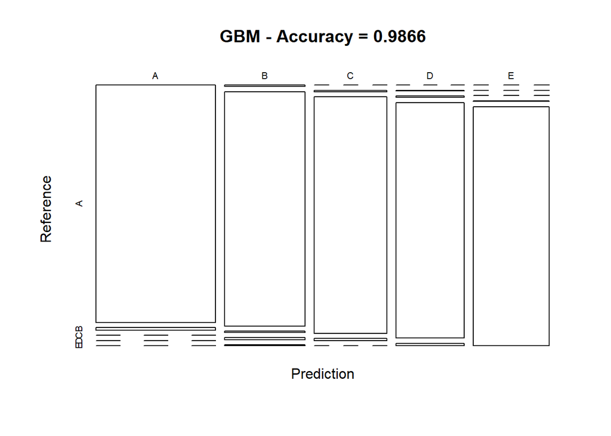

```r
plot(cfMatGBM$table, col = cfMatGBM$byClass,
     main = paste("GBM - Accuracy =", round(cfMatGBM$overall['Accuracy'], 4)))
```

## Prediction

The Random Forest model is used to predict the 20 results of the questionnaire for qualification

```r
predictTest<- predict(modFitRf, newdata=testing)
predictTest
```

```
##  [1] B A B A A E D B A A B C B A E E A B B B
## Levels: A B C D E
```